# 累乗と平方根

累乗と平方根は、数式を記述するのに活躍します。

### 累乗とは？

同じ数または文字を何度か掛け合わせることを、累乗といいます。
例えば、 $$3\times 3\times 3\times 3\times 3$$ は、3を5つかけていますが、次のように表すことができます。

$$3^5$$

これは、3の5乗と読みます。
以上を踏まえて、$x$、$y$、を変数、$a$を定数として次のように表すことができます。 $$y=a^x$$ このとき、$x$、$y$、$a$は整数だけではなく小数になることもあります。

また、累乗に関して、以下の関係が成り立ちます。
$$(x^a)^b=x^{ab}$$ $$x^ax^b=x^{a+b}$$

### 累乗をコードで実装

数式$y=a^x$をコードで実装します。

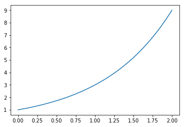

```python
import numpy as np
import matplotlib.pyplot as plt

def my_func(x):
    a = 3
    return 3**x  # 3^x

x = np.linspace(0, 2)
y = my_func(x)  # y = f(x)

plt.plot(x, y)
plt.show()
```

### 平方根とは？

以下の関係を考えます。 $$y=x^a$$ このとき、$(x^a)^b=x^{ab}$により、$a=\frac{1}{2}$であれば、$y$を2乗すると$x$になります。

$$ \begin{aligned} \\ y^2 & = (x^{\frac{1}{2}})^2 \\ & = x \end{aligned} $$

このような、2乗して$x$になる$y$のことを、$x$の**平方根**といいます。  
平方根は次のように記述することも多いです。

$$y=\sqrt x$$

### 平方根をコードで実装

数式$y=\sqrt x$をコードで実装します。

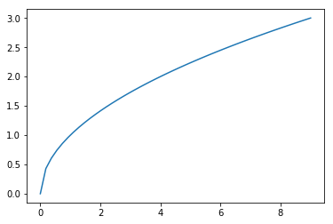

```python
import numpy as np
import matplotlib.pyplot as plt

def my_func(x):
    return np.sqrt(x)  # xの平方根

x = np.linspace(0, 9)
y = my_func(x)  # y = f(x)

plt.plot(x, y)
plt.show()
```

### 演習:

コードを補完し、以下の数式のグラフを描画しましょう。 $$y=2^x$$ $$y=\sqrt x + 1$$

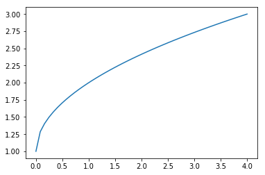

```python
import numpy as np
import matplotlib.pyplot as plt

def my_func(x):
#     return 2^x # 数式のコード
    return np.sqrt(x) + 1

x = np.linspace(0, 4)
y = my_func(x)  # y = f(x)

plt.plot(x, y)
plt.show()
```